# Homework 1 cahpter2

Author

Guibril Ramde

## 2.10 Exercises

**2.1**

```r
library(fpp3)
library(tsibble)
help(aus_production)
# A tsibble: 218 x 7 [1Q]
  # Quarter  Beer Tobacco Bricks Cement Electricity   Gas
 #    <qtr> <dbl>   <dbl>  <dbl>  <dbl>       <dbl> <dbl>
 #1 1956 Q1   284    5225    189    465        3923     5
# 2 1956 Q2   213    5178    204    532        4436     6
# 3 1956 Q3   227    5297    208    561        4806     7
# 4 1956 Q4   308    5681    197    570        4418     6


help(vic_elec)
# A tsibble: 52,608 x 5 [30m] <Australia/Melbourne>
  # Time                Demand Temperature Date       Holiday
  # <dttm>               <dbl>       <dbl> <date>     <lgl>
# 1 2012-01-01 00:00:00  4383.        21.4 2012-01-01 TRUE
# 2 2012-01-01 00:30:00  4263.        21.0 2012-01-01 TRUE
# 3 2012-01-01 01:00:00  4049.        20.7 2012-01-01 TRUE

help(pelt)
# A tsibble: 91 x 3 [1Y]
   # Year  Hare  Lynx
 #  <dbl> <dbl> <dbl>
# 1  1845 19580 30090
# 2  1846 19600 45150
# 3  1847 19610 49150
# ℹ 81 more rows

help(gafa_stock)
# A tsibble: 5,032 x 8 [!]
# Key:       Symbol [4]
   #Symbol Date        Open  High   Low Close Adj_Close    Volume
   #<chr>  <date>     <dbl> <dbl> <dbl> <dbl>     <dbl>     <dbl>
# 1 AAPL   2014-01-02  79.4  79.6  78.9  79.0      67.0  58671200
# 2 AAPL   2014-01-03  79.0  79.1  77.2  77.3      65.5  98116900
# ℹ 5,022 more rows
```

> Bricks in aus_production is a quarterly data

> Demand from vic_elec is half hourly data

> Lynx from pelt is a yearly data

> Close from gafa_stock is daily data

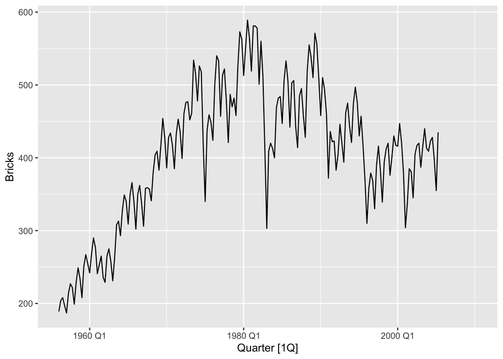

```r
aus_production |>
  autoplot(Bricks, na.rm =TRUE)
```

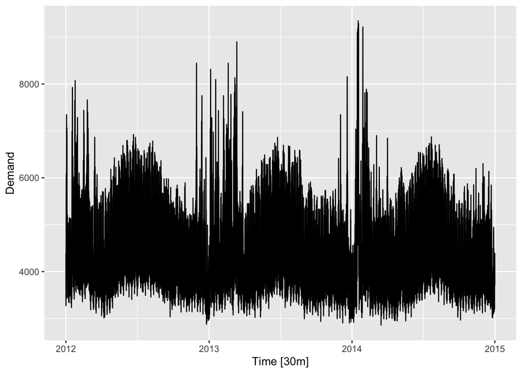

```r
vic_elec |>
  autoplot(Demand)
```

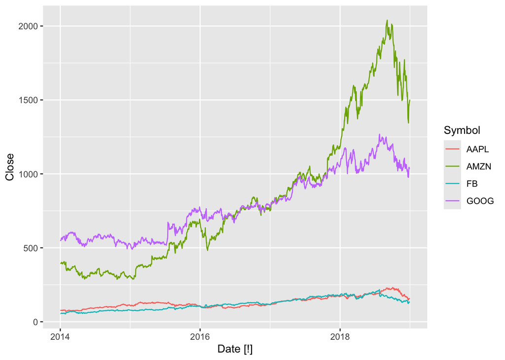

```r
gafa_stock |>
  autoplot(Close)
```

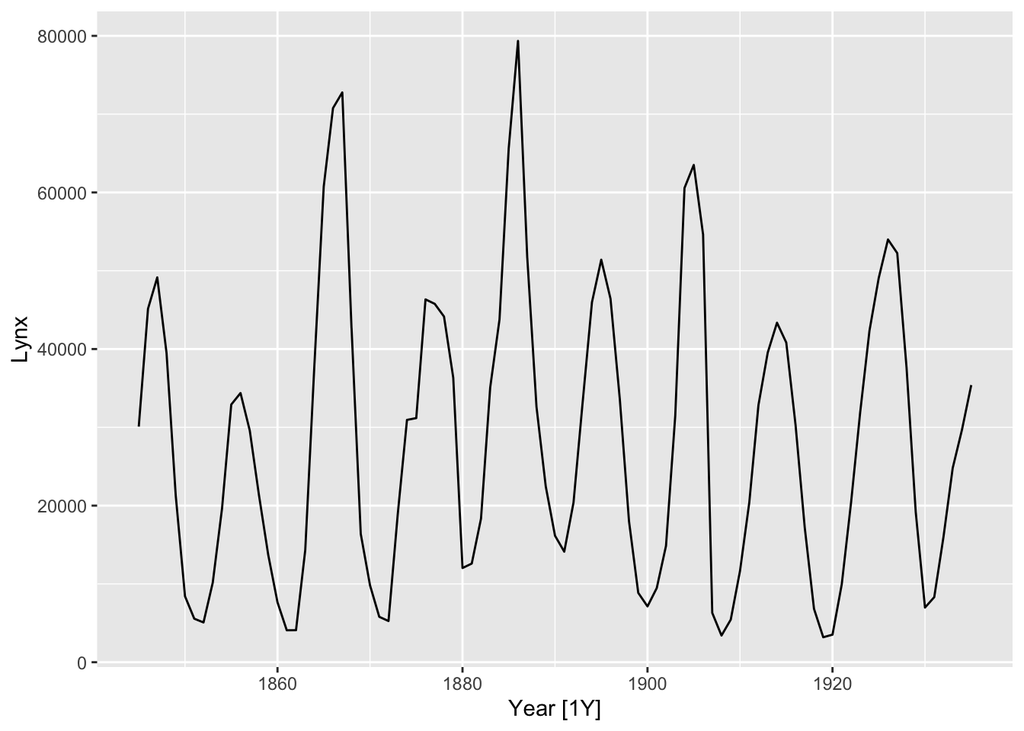

```r
pelt |>
  autoplot(Lynx)
```

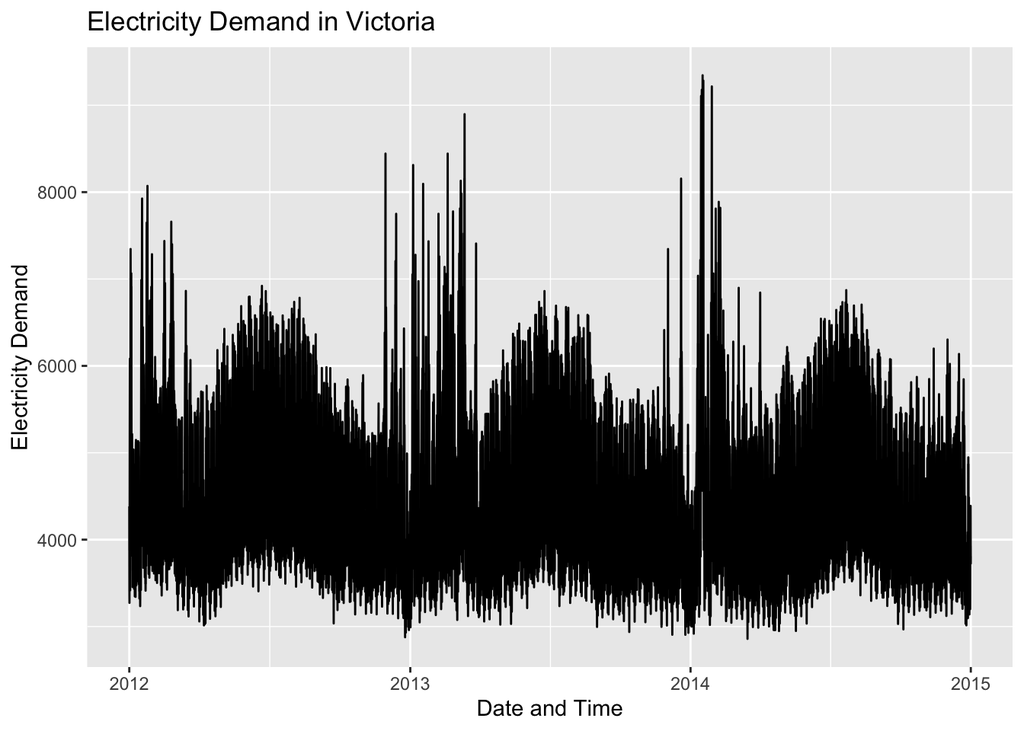

```r
vic_elec |>
  autoplot(Demand) +
  labs(
    title = "Electricity Demand in Victoria",
    x = "Date and Time",
    y = "Electricity Demand"
  )
```

**2.2**

```r
gafa_stock |>
  group_by(Symbol) |>
  filter(Close == max(Close)) |>
  select(Symbol, Date, Close)
```

```
# A tsibble: 4 x 3 [!]
# Key:       Symbol [4]
# Groups:    Symbol [4]
  Symbol Date       Close
  <chr>  <date>     <dbl>
1 AAPL   2018-10-03  232.
2 AMZN   2018-09-04 2040.
3 FB     2018-07-25  218.
4 GOOG   2018-07-26 1268.
```

**2.3**

```r
load_data <- read.csv("tute1.csv")
load_data
```

```
       Quarter  Sales AdBudget   GDP
1   1981-03-01 1020.2    659.2 251.8
2   1981-06-01  889.2    589.0 290.9
3   1981-09-01  795.0    512.5 290.8
4   1981-12-01 1003.9    614.1 292.4
5   1982-03-01 1057.7    647.2 279.1
6   1982-06-01  944.4    602.0 254.0
7   1982-09-01  778.5    530.7 295.6
8   1982-12-01  932.5    608.4 271.7
9   1983-03-01  996.5    637.9 259.6
10  1983-06-01  907.7    582.4 280.5
11  1983-09-01  735.1    506.8 287.2
12  1983-12-01  958.1    606.7 278.0
13  1984-03-01 1034.1    658.7 256.8
14  1984-06-01  992.8    614.9 271.0
```

[output cut: 86 more lines]

a. read the data into R

```r
tute1 <- readr::read_csv("tute1.csv")
view(tute1)
```

b. convert the data to time series

```r
mytimeseries <- tute1 |>
  mutate(Quarter = yearquarter(Quarter)) |>
  as_tsibble(index = Quarter)
```

c. construct time series plots of each of the three series

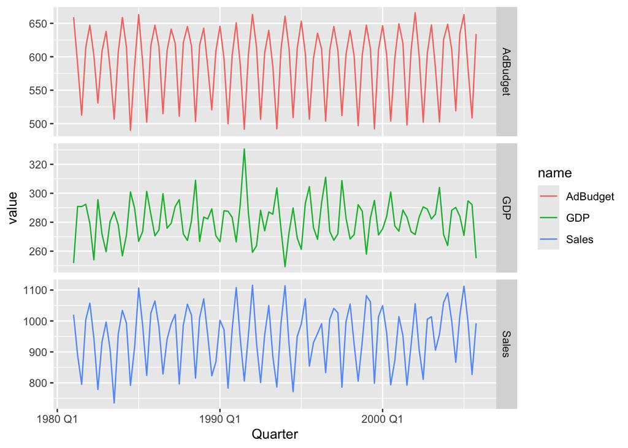

```r
mytimeseries |>
  pivot_longer(-Quarter) |>
  ggplot(aes(x = Quarter, y = value, colour = name)) +
  geom_line() +
  facet_grid(name ~ ., scales = "free_y")
```

not including facet_grid the 03 name get store in the same value making it one plot, which might be confusing during interpretation.

**2.4**

```r
library(USgas)
names(us_total)
```

```
[1] "year"  "state" "y"
```

```r
#install.packages("USgas")

us_total <- us_total |>
  as_tsibble(key = state, index =  year)
us_total
```

```
# A tsibble: 1,266 x 3 [1Y]
# Key:       state [53]
    year state        y
   <int> <chr>    <int>
 1  1997 Alabama 324158
 2  1998 Alabama 329134
 3  1999 Alabama 337270
 4  2000 Alabama 353614
 5  2001 Alabama 332693
 6  2002 Alabama 379343
 7  2003 Alabama 350345
 8  2004 Alabama 382367
 9  2005 Alabama 353156
10  2006 Alabama 391093
# ℹ 1,256 more rows
```

```r
is_tsibble(us_total)
```

```
[1] TRUE
```

c. Plot the annual natural gas

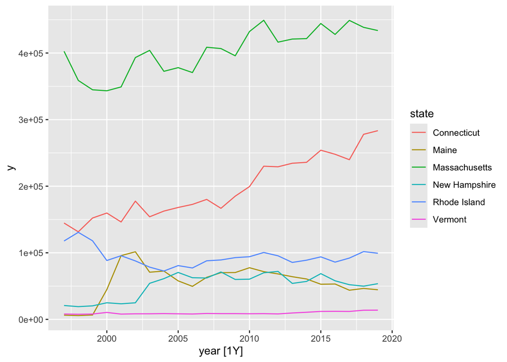

```r
new_england <- c(
   "Maine",
  "Vermont",
  "New Hampshire",
  "Massachusetts",
  "Connecticut",
  "Rhode Island"

)
us_total |>
  filter(state %in% new_england) |>
  autoplot(y)
```

**2.5 a. read tourism.xlsx**

```r
load_data_t <- readxl::read_excel("tourism.xlsx")
load_data_t
```

```
# A tibble: 24,320 × 5
   Quarter    Region   State           Purpose  Trips
   <chr>      <chr>    <chr>           <chr>    <dbl>
 1 1998-01-01 Adelaide South Australia Business  135.
 2 1998-04-01 Adelaide South Australia Business  110.
 3 1998-07-01 Adelaide South Australia Business  166.
 4 1998-10-01 Adelaide South Australia Business  127.
 5 1999-01-01 Adelaide South Australia Business  137.
 6 1999-04-01 Adelaide South Australia Business  200.
 7 1999-07-01 Adelaide South Australia Business  169.
 8 1999-10-01 Adelaide South Australia Business  134.
 9 2000-01-01 Adelaide South Australia Business  154.
10 2000-04-01 Adelaide South Australia Business  169.
# ℹ 24,310 more rows
```

b.create tsibble

```r
tourism_data <- load_data_t |>
  mutate(Quarter = yearquarter(Quarter)) |>
  as_tsibble(key = c(Region,State, Purpose), index = Quarter)
tourism_data
```

```
# A tsibble: 24,320 x 5 [1Q]
# Key:       Region, State, Purpose [304]
   Quarter Region   State           Purpose  Trips
     <qtr> <chr>    <chr>           <chr>    <dbl>
 1 1998 Q1 Adelaide South Australia Business  135.
 2 1998 Q2 Adelaide South Australia Business  110.
 3 1998 Q3 Adelaide South Australia Business  166.
 4 1998 Q4 Adelaide South Australia Business  127.
 5 1999 Q1 Adelaide South Australia Business  137.
 6 1999 Q2 Adelaide South Australia Business  200.
 7 1999 Q3 Adelaide South Australia Business  169.
 8 1999 Q4 Adelaide South Australia Business  134.
 9 2000 Q1 Adelaide South Australia Business  154.
10 2000 Q2 Adelaide South Australia Business  169.
# ℹ 24,310 more rows
```

```r
#checking if it is identical
tourism
```

```
# A tsibble: 24,320 x 5 [1Q]
# Key:       Region, State, Purpose [304]
   Quarter Region   State           Purpose  Trips
     <qtr> <chr>    <chr>           <chr>    <dbl>
 1 1998 Q1 Adelaide South Australia Business  135.
 2 1998 Q2 Adelaide South Australia Business  110.
 3 1998 Q3 Adelaide South Australia Business  166.
 4 1998 Q4 Adelaide South Australia Business  127.
 5 1999 Q1 Adelaide South Australia Business  137.
 6 1999 Q2 Adelaide South Australia Business  200.
 7 1999 Q3 Adelaide South Australia Business  169.
 8 1999 Q4 Adelaide South Australia Business  134.
 9 2000 Q1 Adelaide South Australia Business  154.
10 2000 Q2 Adelaide South Australia Business  169.
# ℹ 24,310 more rows
```

```r
key_vars(tourism)
```

```
[1] "Region"  "State"   "Purpose"
```

```r
index_var(tourism)
```

```
[1] "Quarter"
```

c**. Max overnight trip**

```r
max_trip <- tourism_data |>
  group_by(Region, Purpose) |>
  summarise(avg_trips = mean(Trips), .groups = "drop") |>
  filter(avg_trips == max(avg_trips))


max_trip
```

```
# A tsibble: 1 x 4 [1Q]
# Key:       Region, Purpose [1]
  Region    Purpose  Quarter avg_trips
  <chr>     <chr>      <qtr>     <dbl>
1 Melbourne Visiting 2017 Q4      985.
```

d.Create a new tsibble which combine region and purpose

```r
tourism_new <- tourism_data |>
  group_by(State) |>
  index_by(Quarter) |>
  summarise(Trips = sum(Trips))

tourism_new
```

```
# A tsibble: 640 x 3 [1Q]
# Key:       State [8]
   State Quarter Trips
   <chr>   <qtr> <dbl>
 1 ACT   1998 Q1  551.
 2 ACT   1998 Q2  416.
 3 ACT   1998 Q3  436.
 4 ACT   1998 Q4  450.
 5 ACT   1999 Q1  379.
 6 ACT   1999 Q2  558.
 7 ACT   1999 Q3  449.
 8 ACT   1999 Q4  595.
 9 ACT   2000 Q1  600.
10 ACT   2000 Q2  557.
# ℹ 630 more rows
```

**2.8 Use the following graphics functions**

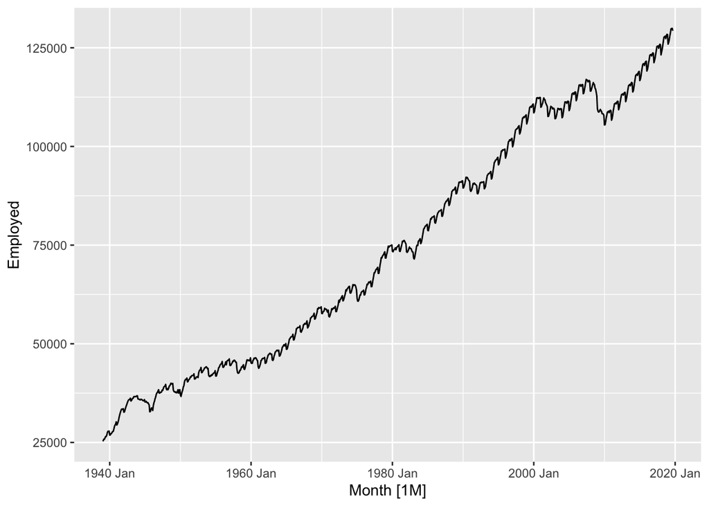

```r
total_private <- us_employment |>
  filter(Title == "Total Private")

total_private |> autoplot(Employed)
```

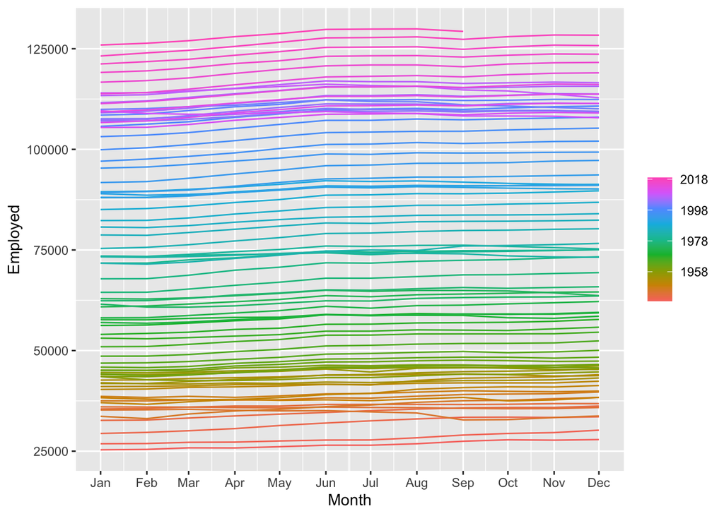

```r
total_private |> gg_season(Employed)
```

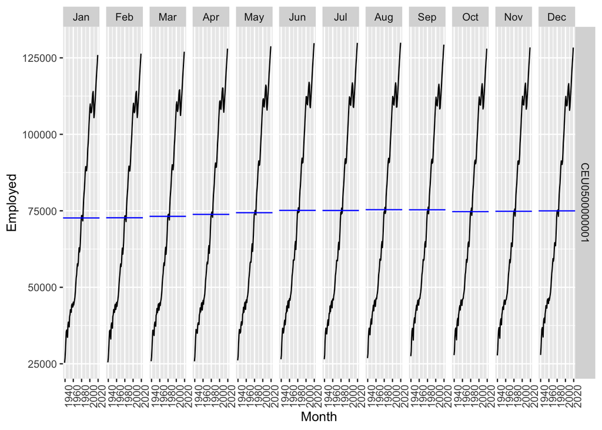

```r
total_private |> gg_subseries(Employed)
```

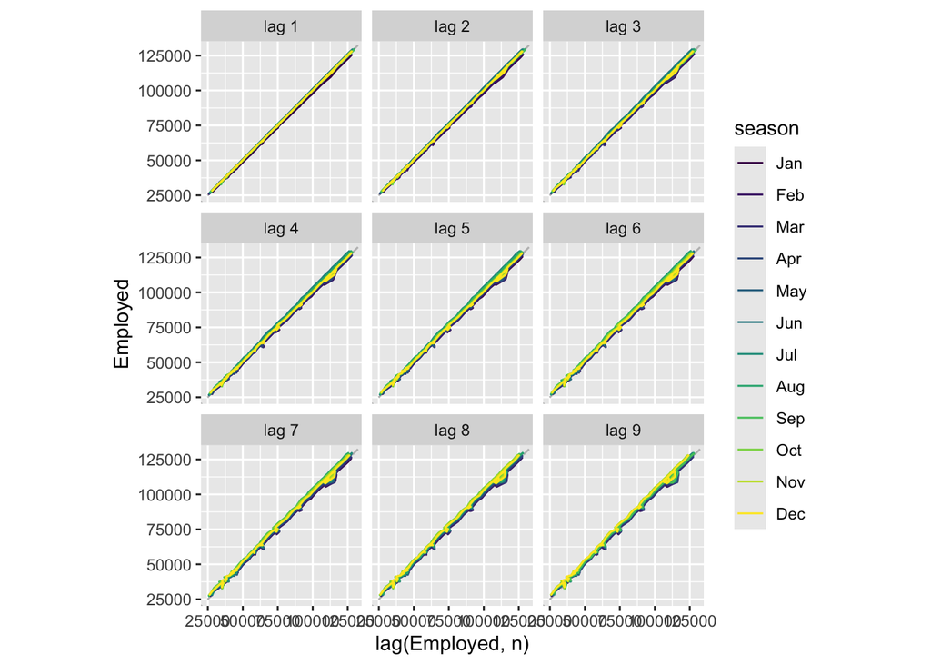

```r
total_private |> gg_lag(Employed)
```